**KNN**

According to this algorithm, which is used in classification, feature extraction during classification is used to look at the closeness of the new individual to be categorized to k of the previous individuals. For example, you want to classify a new element for k = 3. in this case the nearest 3 of the old classified elements are taken. If these elements are included in the class, the new element is also included in that class. The euclide distance can be used in the distance calculation.

# Project - Classify Type of Patient from the biomechanical features of orthopedic patients.

# Install the necessary libraries

```python
# importing necessary libraries
import numpy as np
import pandas as pd
import matplotlib.pyplot as plt
import seaborn as sns

%matplotlib inline
```

# import data 2C_weka.csv for 2 Class Classifcation.

```python
_2c = pd.read_csv("./2Classdata.csv")
```

# Explore the data set.Get necessary information about the data.

Look at the head and tail of dataset. Find the missing value. Look at the unique values of class values. Look at the distribution of class values and other attributes. Get the datatype information about the dataset Plot the distribution of different classes for pelvic_radius and sacral_slope for visualization.

```python
_2c.head()
```

|  | pelvic_incidence | pelvic_tilt numeric | lumbar_lordosis_angle | sacral_slope | pelvic_radius | degree_spondylolisthesis | class |
| --- | --- | --- | --- | --- | --- | --- | --- |
| 0 | 63.027818 | 22.552586 | 39.609117 | 40.475232 | 98.672917 | -0.254400 | Abnormal |
| 1 | 39.056951 | 10.060991 | 25.015378 | 28.995960 | 114.405425 | 4.564259 | Abnormal |
| 2 | 68.832021 | 22.218482 | 50.092194 | 46.613539 | 105.985135 | -3.530317 | Abnormal |
| 3 | 69.297008 | 24.652878 | 44.311238 | 44.644130 | 101.868495 | 11.211523 | Abnormal |
| 4 | 49.712859 | 9.652075 | 28.317406 | 40.060784 | 108.168725 | 7.918501 | Abnormal |

```python
_2c.tail()
```

|  | pelvic_incidence | pelvic_tilt numeric | lumbar_lordosis_angle | sacral_slope | pelvic_radius | degree_spondylolisthesis | class |
| --- | --- | --- | --- | --- | --- | --- | --- |
| 305 | 47.903565 | 13.616688 | 36.000000 | 34.286877 | 117.449062 | -4.245395 | Normal |
| 306 | 53.936748 | 20.721496 | 29.220534 | 33.215251 | 114.365845 | -0.421010 | Normal |
| 307 | 61.446597 | 22.694968 | 46.170347 | 38.751628 | 125.670725 | -2.707880 | Normal |
| 308 | 45.252792 | 8.693157 | 41.583126 | 36.559635 | 118.545842 | 0.214750 | Normal |
| 309 | 33.841641 | 5.073991 | 36.641233 | 28.767649 | 123.945244 | -0.199249 | Normal |

```python
# Checking for empty or NaN data in all the column
for column in _2c.columns:
    data = _2c[column].isnull().sum()
    print("Checking null in column '{}' and its {}.".format(column,data))
```

```
Checking null in column 'pelvic_incidence' and its 0.
Checking null in column 'pelvic_tilt numeric' and its 0.
Checking null in column 'lumbar_lordosis_angle' and its 0.
Checking null in column 'sacral_slope' and its 0.
Checking null in column 'pelvic_radius' and its 0.
Checking null in column 'degree_spondylolisthesis' and its 0.
Checking null in column 'class' and its 0.
```

- On checking the columns in _2c dataframe I see no null values in it.

```python
# Getting the unique values in column Values
_2c['class'].unique()
```

```
array(['Abnormal', 'Normal'], dtype=object)
```

- The unique values in column class are Abnormal and Normal.

```
array([[<matplotlib.axes._subplots.AxesSubplot object at 0x00000235090CFEF0>,
      dtype=object)
```

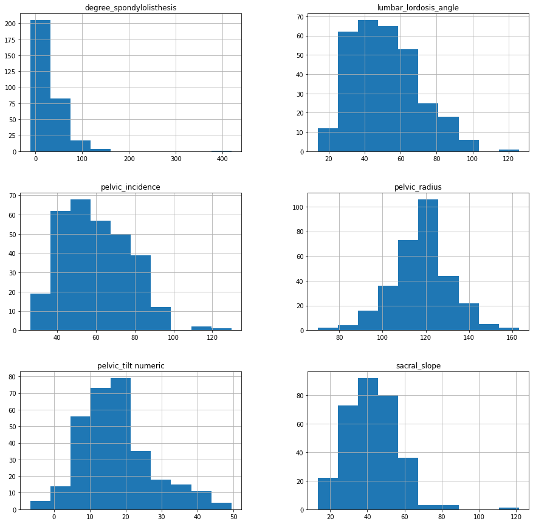

```python
pd.DataFrame.hist(_2c, figsize=(15,15))
```

### Conclusion on Distribution of the Independent Varibles

- The data points in column pelvic_radius is normally distributed.
- pelvic_tilt numeric,sacral_slope,pelvice_incidence,lumbar_lordosis_angle are columns that has a right skew.
- degree_spondylolisthesis starts with a peak and then skews to the right.

#### Note: Since the class variable is a categorical data we cannot draw major consulsions apart from the number of records that are Normal/Abnormal.

### Datatype information on the dataset

```python
_2c.info()
```

```
<class 'pandas.core.frame.DataFrame'>
RangeIndex: 310 entries, 0 to 309
Data columns (total 7 columns):
pelvic_incidence            310 non-null float64
pelvic_tilt numeric         310 non-null float64
lumbar_lordosis_angle       310 non-null float64
sacral_slope                310 non-null float64
pelvic_radius               310 non-null float64
degree_spondylolisthesis    310 non-null float64
class                       310 non-null object
dtypes: float64(6), object(1)
memory usage: 17.0+ KB
```

### Conclusion:

- All the columns in the dataset except for 'class' column, the datatype is float.
- The 'class' column has the object as its datatype.
- We have 310 records in every column.
- We have already verified that non of the column has empty or NaN as value.

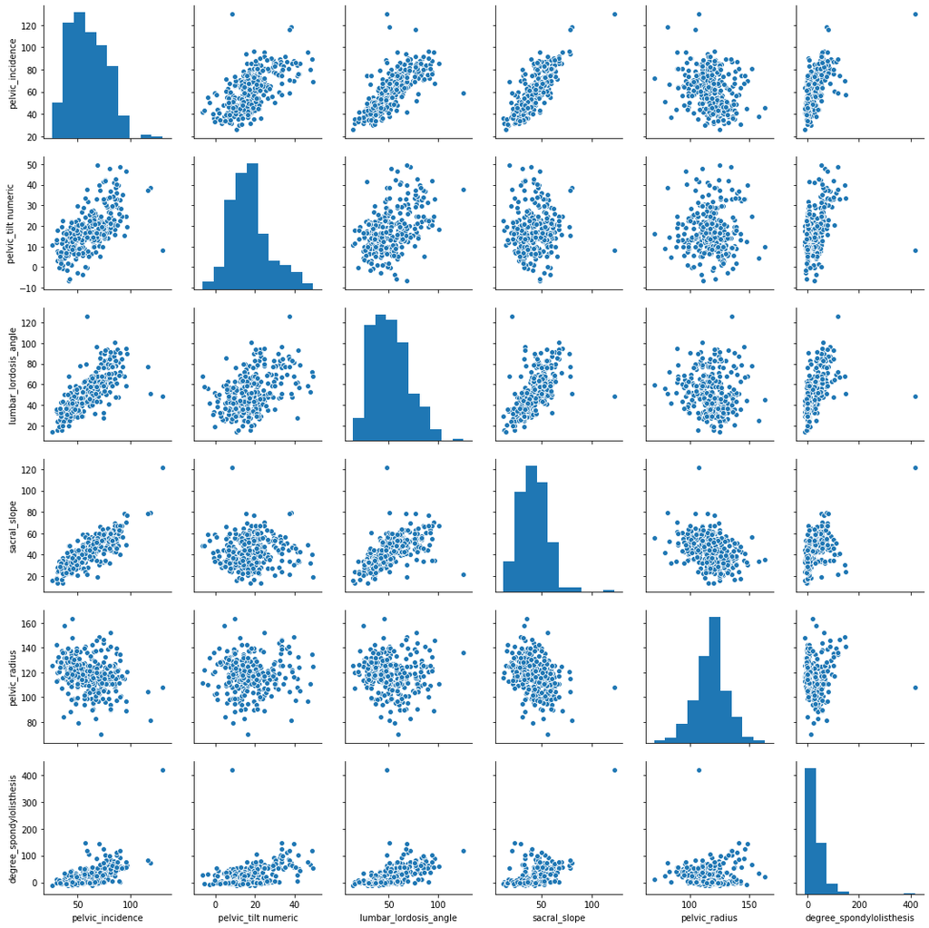

```python
sns.pairplot(_2c)
```

# Encode the Class variable to integer.

```python
_2c['classnumeric'] = _2c['class'].map({'Normal': 1, 'Abnormal': 0})
```

```python
_2c.head()
```

|  | pelvic_incidence | pelvic_tilt numeric | lumbar_lordosis_angle | sacral_slope | pelvic_radius | degree_spondylolisthesis | class | classnumeric |
| --- | --- | --- | --- | --- | --- | --- | --- | --- |
| 0 | 63.027818 | 22.552586 | 39.609117 | 40.475232 | 98.672917 | -0.254400 | Abnormal | 0 |
| 1 | 39.056951 | 10.060991 | 25.015378 | 28.995960 | 114.405425 | 4.564259 | Abnormal | 0 |
| 2 | 68.832021 | 22.218482 | 50.092194 | 46.613539 | 105.985135 | -3.530317 | Abnormal | 0 |
| 3 | 69.297008 | 24.652878 | 44.311238 | 44.644130 | 101.868495 | 11.211523 | Abnormal | 0 |
| 4 | 49.712859 | 9.652075 | 28.317406 | 40.060784 | 108.168725 | 7.918501 | Abnormal | 0 |